# Network Analytics on HR Data: A Practical Perspective and 3 Case Studies

Posted by Andre Vermeji

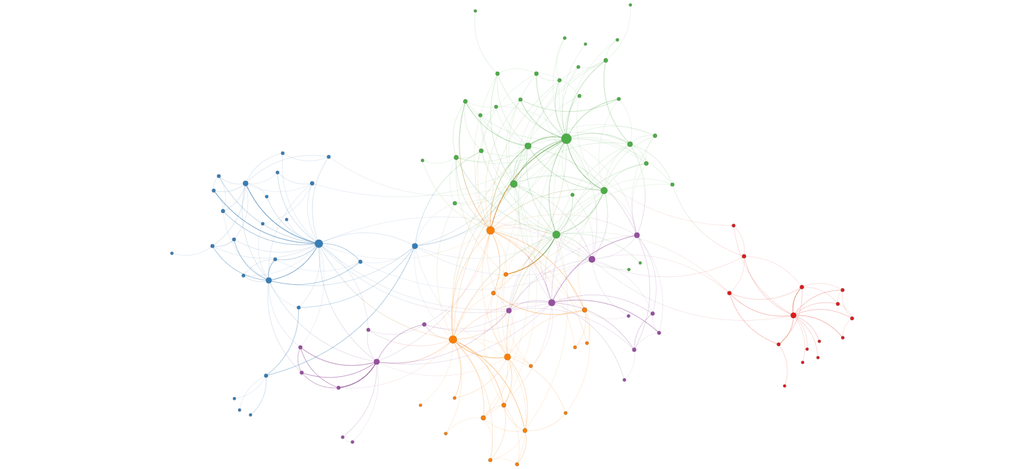

Have you always wanted to measure collaboration within your company and improve your decision-making accordingly? Network analytics can guide you on your way. This post includes 3 case studies and a fully interactive visualization to get you started.

Internal and external communication and collaboration within and between organisations have traditionally been hard to measure. Interestingly, when coupling the right data sources with the principles of social network analysis and network science, we can enable ourselves to gain a whole new, connected perspective on the informal hierarchies existing within organisations. In this way, it actually becomes possible to tangibly analyse and visualize concepts which were deemed too ‘soft’ to analyse before. This article guides you through what a network actually is, and provides you with three real-life cases within the realm of HR to showcase the key added value of a network view on HR data.

### What’s a network?

Essentially, a network consists of a collection of data points and the connections between them (as you can see in the example network above). In an HR context, data points (or in network parlor, nodes) could be persons, skills, departments or even entire organisations, while the connections (or, edges) between them could be based on collaboration on projects or overall communication frequency. A wide variety of metrics and algorithms exist for the analysis of networks, all firmly grounded in Social Network Analysis (SNA) – an academic discipline which has been applied since at least the 1930s. More recently, academics have even given rise to a whole new field dedicated solely to the study of (complex) networks, dubbed Network Science.

**Related: [7 HR analytics examples](https://www.aihr.com/blog/predictive-analytics-human-resources/)**

**Related: A list of [Human Resources metrics](https://www.aihr.com/blog/14-hr-metrics-examples/)**

### From data to network

Of course, we do need the right data sources in order to be able to actually construct these networks. Luckily, a lot of data within the context of HR is already available. Hidden within company social networks such as Yammer and Chatter are countless interactions; project collaborations between people can be gathered from time registration systems; and internal documents can be scraped to extract their co-authorship information. When this kind of information is out of reach, it is common practice to use short questionnaires: for example, asking employees with whom they collaborate most often and how that collaboration takes place (face-to-face, telephone, e-mail, etc.) can already provide a deep view on the informal networks existing within a department or organisation.

### Network Analytics & HR Data in practice

The practical value of network analysis in an HR context is of course best explained through real-life cases based on some of our recent client projects. Read on to find some of these below.

### Case 1: Optimizing communication and collaboration for a Dutch insurance company

Recently, a major Dutch insurance company took the decision to move hundreds of its employees to a brand new location. To improve overall collaboration and communication between the various divisions to be located at the new location, our client wanted to optimize the actual physical locations of the various teams in the building by looking at the way they currently collaborated and communicated. Data to provide these insights was however not readily available.

To gather the necessary data, we set out short 3-minute questionnaires to all employees. We asked employees (1) which other departments were most important for carrying out their day-to-day work, (2) how often they communicated with these departments, (3) how they actually communicated with these departments (for example physical meetings, phone, e-mail, etc.) and (4) how important physical proximity of these departments was for carrying out their jobs.

[figure not shown]

*Connected departments within the insurance company*

When all the data was gathered, we constructed network analyses and visualizations which showed all departments and the various interconnections between them. Using a customized interactive visualization, we then enabled our client to explore the connections between all departments and filter by communication types, frequency and importance of proximity to be able to gain insights from various angles.

**Related: How to build an [HR dashboard](https://www.aihr.com/blog/hr-reporting-hr-report-hr-dashboard/)**

One of the major insights from the analysis was that the IT department played a key connecting role between various product-focused departments, based on the frequent face-to-face meetings employees had with other departments. In the final layout of the building, this department was therefore placed at a central location to further stimulate and optimize their communication and collaboration with others. This has the potential to significantly improve idea-sharing, thereby decreasing lead times and related operational costs in IT-enabled product innovation.

### Case 2: Improved knowledge-sharing for a globally operating consumer goods manufacturer

For a major consumer goods manufacturer, we analysed and visualized internal expertise and collaboration networks to provide a data-driven overview of knowledge-sharing within the organisation. Our client had innovation centers across the world, with many Research & Development (R&D) employees working together at each location. Due to the sheer size of the organisation, it was hard for employees to actually locate each other, and thereby each other’s knowledge. Essentially, knowledge was sourced mostly within the same divisions. At the same time, our client realized that cross-disciplinary knowledge sharing could benefit the innovation process significantly.

Using a mix of data sources in the context of innovation such as scientific publications, patents and conference proceedings, we gathered information on collaborations which had taken place within the organisation during a 5-year time-frame. These data sources include a lot of information on authors, inventors and their co-publications, and thus serve as a great initial source for mapping internal knowledge sharing.

[figure not shown]

*Technology clustering and knowledge sharing within the consumer goods company*

[figure not shown]

Subsequently, we provided two interactive complementary perspectives on these data sources in a customized dashboard: technology and topic networks to show the connectedness between individual technologies/topics and the activity clusters they reside in, as well as expertise networks to get a fine-grained view on the actual relations between individuals, teams and the business areas they operate in.

**Related: An overview of key [employee performance metrics](https://www.aihr.com/blog/employee-performance-metrics/)**

The interactive visualizations allowed our client to locate internal knowledge significantly quicker, increase interdisciplinary knowledge sharing for new idea generation, and generally make better use of the available knowledge and experience within the organisation. This subsequently had the potential to lead to a decrease in reliance on externally sourced knowledge and associated partner search costs, and generally sped up the ideation process due to improved knowledge combinations.

### Case 3: Optimizing human resource allocation for a European retailer

Our client, a European retailer, had plans to construct a brand new distribution center for its operations in one of its key markets. Apart from formal, tree-like organizational hierarchies, it had no tangible view on how to actually structure the offices of the new distribution center in terms of communication between departments and individuals. Similar to the insurance company project described above, the goal was to use this kind of information to optimize the locations of departments across the new distribution center.

Instead of questionnaires, in this project we relied on qualitative data gathering in the form of interviews with employees. The interviews included sections on communication with other departments, including questions on what type of information was shared, whether this was tangible or intangible information (for example, e-mails and documents versus face-to-face meetings and phone conversations), how often this took place, and so forth.

In tooling customized for this project, we made sure to include the ability to slice and dice the dataset based on various filters. For instance, this allowed users to quickly switch between networks based on tangible and intangible communication, or between connections based on types of information shared.

**Related: A guide on how to do [HR reporting](https://www.aihr.com/blog/hr-reporting-hr-report-hr-dashboard/)**

In the end, this enabled the retailer to optimize the actual locations of departments across the distribution centre in a fully data-driven, visual way. This significantly sped up the overall decision-making process with regard to the new distribution centre, and had the potential to decrease throughput times and associated costs for a wide variety of work processes within and across departments.

### Conclusion

The above cases show that the principles of network analytics can be combined with HR data to provide a fresh, visual perspective on internal and external collaboration and communication. This can help businesses to improve knowledge-sharing across the organisation, optimize human resource allocation and generally have the ability to explore datasets in an exciting, interactive way. Another application area within HR is for instance recruitment – mapping networks of interacting individuals within specific knowledge areas outside of the own organisation can prove very worthwhile in finding ‘hidden’ talent pools. If you see any other areas where a connected view on your HR data may be worthwhile, please do let me know in the comments below.

POPULAR

[figure not shown]

[figure not shown]

#### Andre Vermeji

[André Vermeij](https://www.linkedin.com/in/andrevermeij/) is the founder and owner of Kenedict Innovation Analytics. Operating internationally, Kenedict focuses on applying Network Analytics to data sources in a variety of application areas, including HR, Collaboration, Innovation, Procurement and Open Data. Using fully interactive visual analytics powered by tooling developed in-house, Kenedict allows its clients to explore their data from a whole new angle and uncover the actual relationships between data points in an intuitive way. You can reach him via email at andre.vermeij@kenedict.com.

Label

2 Comments

Johan Boesveld

Great article André, thanks!  
After studying your case-studies two thoughts popped up in my mind:

– I was wondering if you ever thought about combining your kind of ‘humanbased’ network analysis with more ‘processbased’ network analysis (processmining) as is done with Disco (Fluxicon) or ProM. The two areas seem to be quite seperated but are (imo) dealing with the same kind of organizational problems. If you’re not already connected, you should have a talk with Anne Rozinat about this subject.

– another but related thought is that in the examples you do not mention the direction of the connections. It would be very interesting to see how information flows through an (hierarchical) organization and influences decisionmaking. Especially in the public sector this knowledge attributes to the transparency of our democratic system. In my opinion this is often over-structured at the bottom (where every penny and every action has to be documented and accountable) but at the other end (where the most important decisions are made) things happen to be more fuzzy and information more tangible.

There you have my two cents worth, but then, you asked for it…

0

Reply

André

Reply to Johan Boesveld

Hi Johan,

Thanks for your comments! Although I’ve heard of it, I’ve actually never used process mining in practice. Would indeed be interesting to investigate in how far these two techniques could be complementary. Will definitely read up on this more!

In terms of the direction of connections, this depends on the type of dataset and related network we’re analyzing. For example, in typical collaboration networks in innovation/R&D (as in the consumer goods case) or between people collaborating across departments (as in the insurance case), the assumption is that connections are reciprocal (or in network analytics terms, undirected): collaboration and the related knowledge-sharing is essentially a two-way process, so that’s why the networks are also modeled that way. When we would have a dataset on decision-making and related one-way information flow in an organization, it would indeed be worthwhile to also take into account the direction of the connections. The data for the retailer was partly structured as such: although most connections were reciprocal, some were deliberately one-way. An example of this is one-way information flow in which an administrative department sends daily information updates to management.

0

Reply

RELATED

View now

August 4, 2021

RELATED

View now

August 3, 2021

RELATED

View now

August 2, 2021

RELATED

View now

July 28, 2021

Learn modern and relevant HR skills, online